# Visualizing the iris flower data set

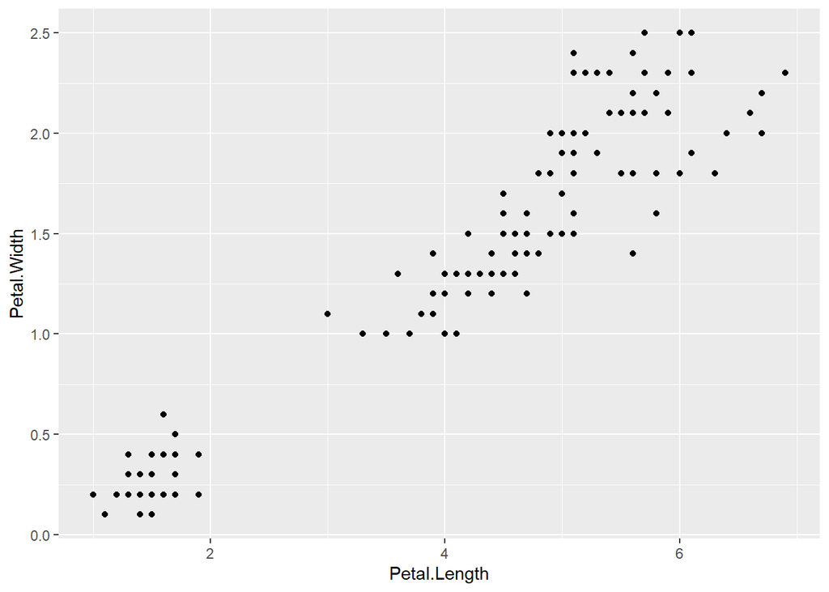

```r
# add data points
ggplot(data = iris) +
  aes(x = Petal.Length, y = Petal.Width) +
  geom_point()
```

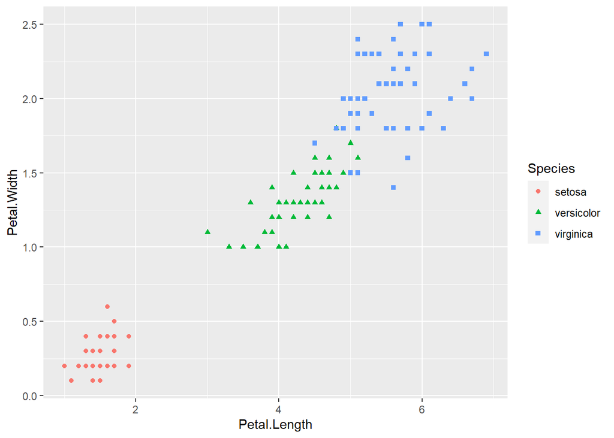

```r
# change color & symbol type
ggplot(data = iris) +
  aes(x = Petal.Length, y = Petal.Width) +
  geom_point(aes(color = Species, shape = Species))
```

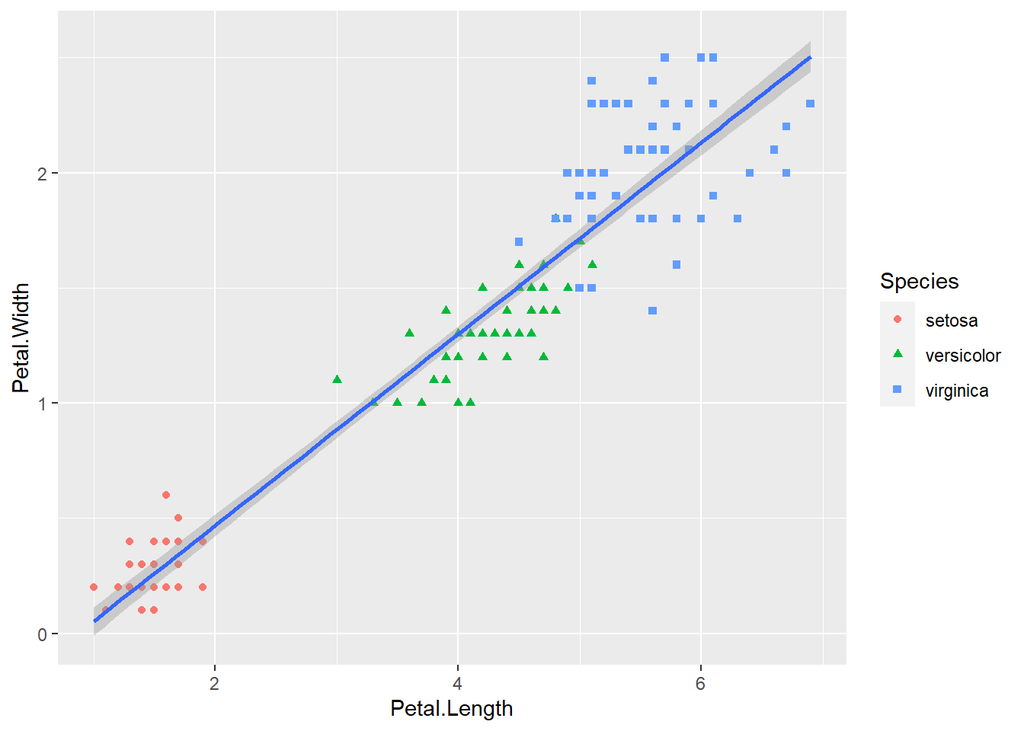

```r
# add trend line
ggplot(data = iris) +
  aes(x = Petal.Length, y = Petal.Width) +
  geom_point(aes(color = Species, shape = Species)) +
  geom_smooth(method = lm)
```

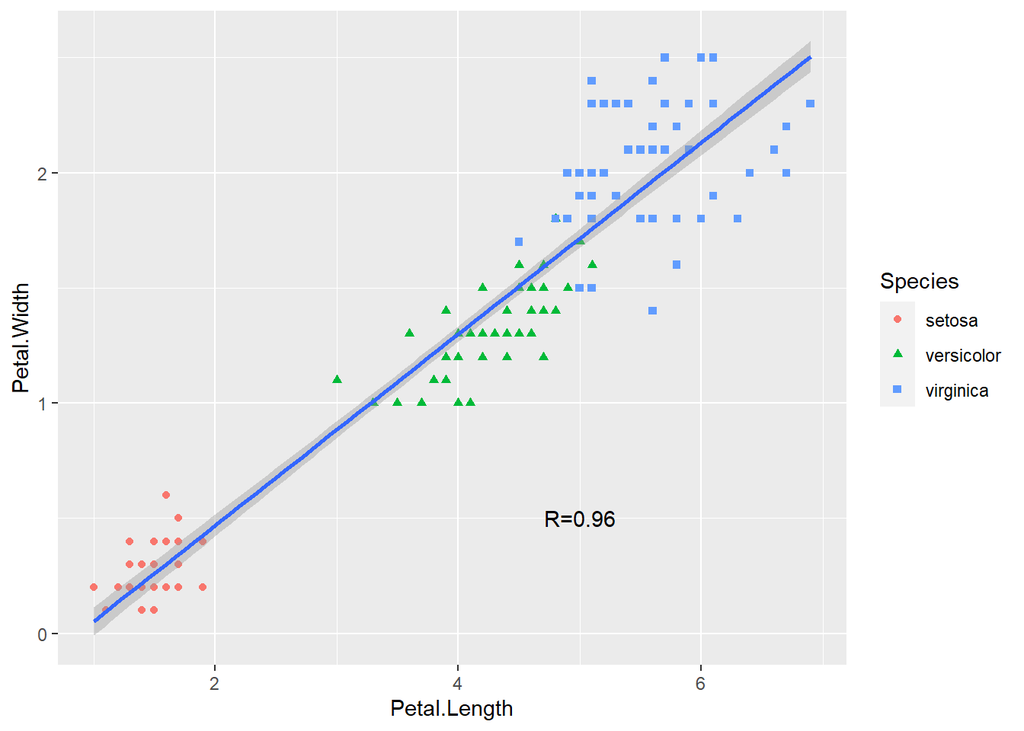

```r
# add annotation text to a specified location by setting coordinates x = , y =
ggplot(data = iris) +
  aes(x = Petal.Length, y = Petal.Width) +
  geom_point(aes(color = Species, shape = Species)) +
  geom_smooth(method = lm) +
  annotate("text", x = 5, y = 0.5, label = "R=0.96")
```

Some ggplot2 commands span multiple lines. The first line defines the plotting space. The ending “+” signifies that another layer ( data points) of plotting is added. Also, the ggplot2 package handles a lot of the details for us. We can easily generate many different types of plots. It is also much easier to generate a plot like Figure @ref(fig:23-5).

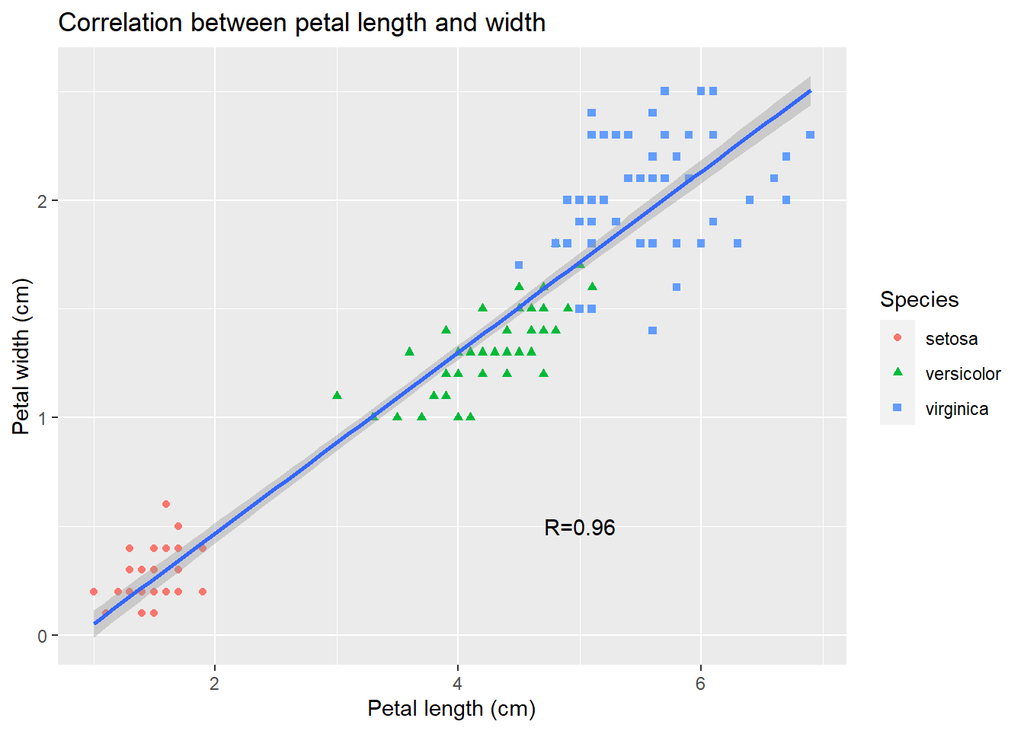

```r
ggplot(iris) +
  aes(x = Petal.Length, y = Petal.Width) + # define space
  geom_point(aes(color = Species, shape = Species)) + # add points
  geom_smooth(method = lm) + # add trend line
  annotate("text", x = 5, y = 0.5, label = "R=0.96") + # annotate with text
  xlab("Petal length (cm)") + # x-axis labels
  ylab("Petal width (cm)") + # y-axis labels
  ggtitle("Correlation between petal length and width") # title
```

As you can see, data visualization using ggplot2 is similar to painting: we first find a blank canvas, paint background, sketch outlines, and then add details.

[figure not shown]

```
>
Create a scatter plot of sepal length vs sepal width, change colors and shapes with species, and add trend line.
```

## Other types of plots with ggplot2

Box plots can be generated by ggplot.

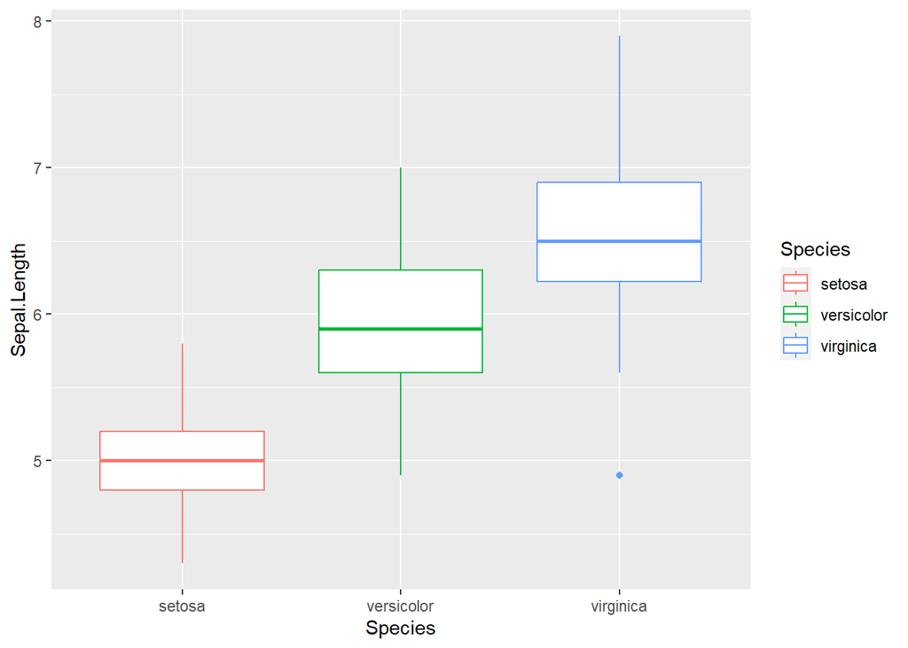

```r
library(ggplot2)
ggplot(data = iris) +
  aes(x = Species, y = Sepal.Length, color = Species) +
  geom_boxplot()
```

Here we use Species, a categorical variable, as x-coordinate. Essentially, we use it to define three groups of data. The y-axis is the sepal length, whose distribution we are interested in. The benefit of using ggplot2 is evident as we can easily refine it.

(ref:22-1) Box plot with raw data points. This is getting increasingly popular.

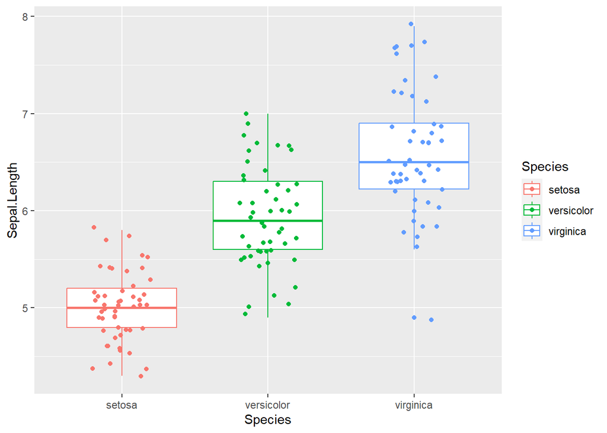

```r
ggplot(data = iris) +
  aes(x = Species, y = Sepal.Length, color = Species) +
  geom_boxplot() +
  geom_jitter(position = position_jitter(0.2))
```

On top of the boxplot, we add another layer representing the raw data points for each of the species. Since lining up data points on a straight line is hard to see, we jittered the relative x-position within each subspecies randomly. We also color-coded three species simply by adding “color = Species”. Many of the low-level graphics details are handled for us by ggplot2 as the legend is generated automatically.

(ref:2-7) Density plot of petal length, grouped by species.

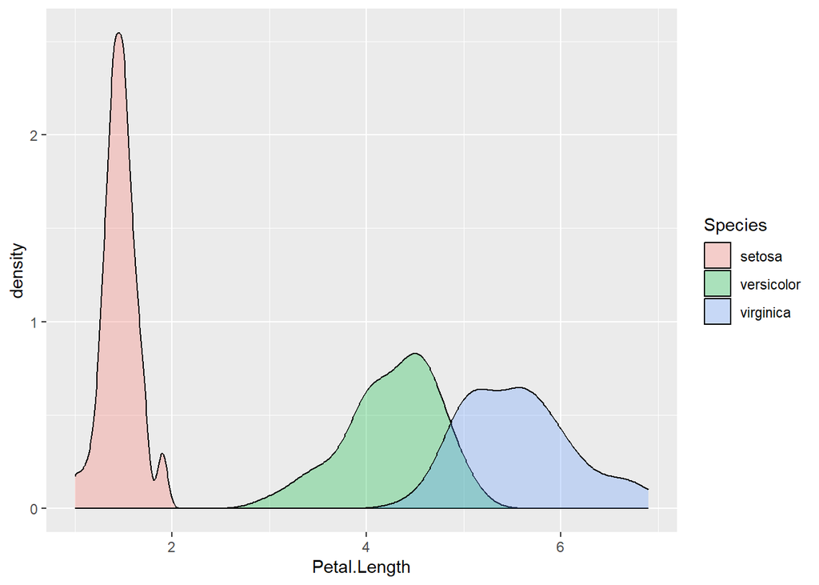

```r
ggplot(data = iris) +
  aes(x = Petal.Length, fill = Species) +
  geom_density(alpha = 0.3)
```

(ref:2-51) Density plot by subgroups using facets.

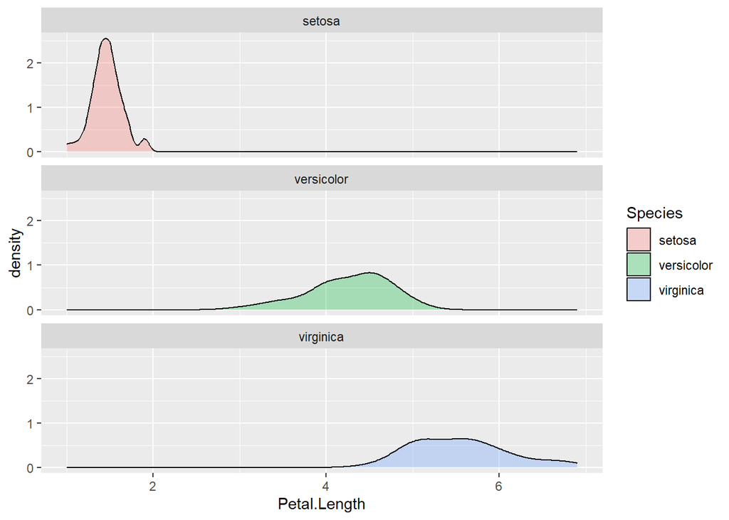

```r
ggplot(data = iris) +
  aes(x = Petal.Length, fill = Species) +
  geom_density(alpha = 0.3) +
  facet_wrap(~Species, nrow = 3)
```

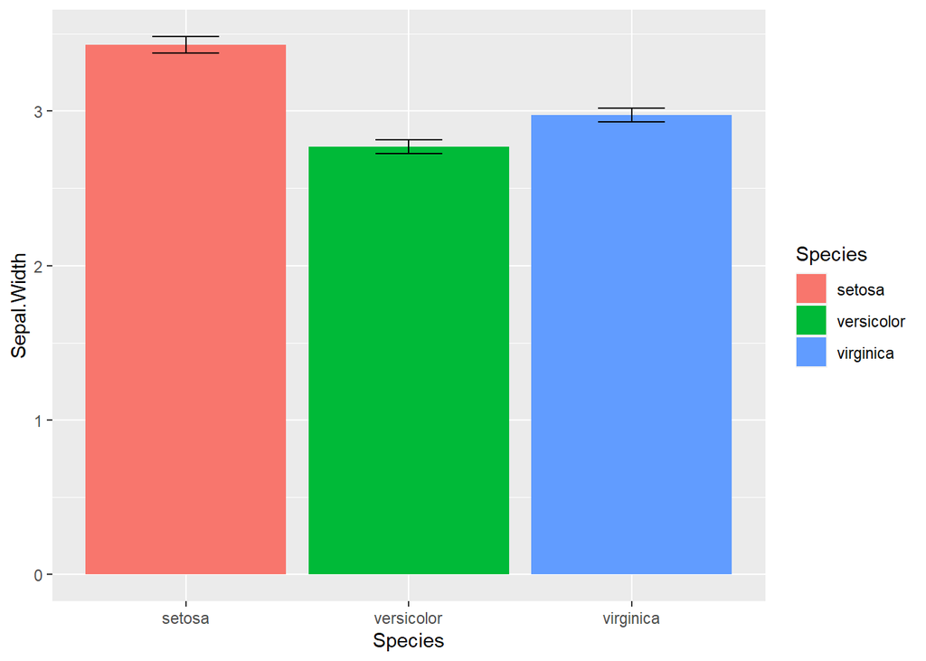

Dynamite Plot

```r
ggplot(iris) +
  aes(x = Species, y = Sepal.Width, fill = Species) +
  stat_summary(geom = "bar", fun = "mean") +
  stat_summary(geom = "errorbar", fun.data = "mean_se", width = .3)
```

The bar plot with error bar in @ref(fig:dynamite) we generated above is called dynamite plots for its similarity. **“The dynamite plots must die!”**, argued renowned statistician Rafael Irizarry in his [blog](https://simplystatistics.org/2019/02/21/dynamite-plots-must-die/). Dynamite plots give very little information; the mean and standard errors just could be printed out. The outliers and overall distribution is hidden. Many scientists have chosen to use this boxplot with jittered points.

```
>
Use boxplot, and density plots to investigate the similarity and differences of petal width of three species in the **iris** dataset.
```

## Hierarchical clustering and heat map

Hierarchical clustering summarizes observations into trees representing the overall similarities.

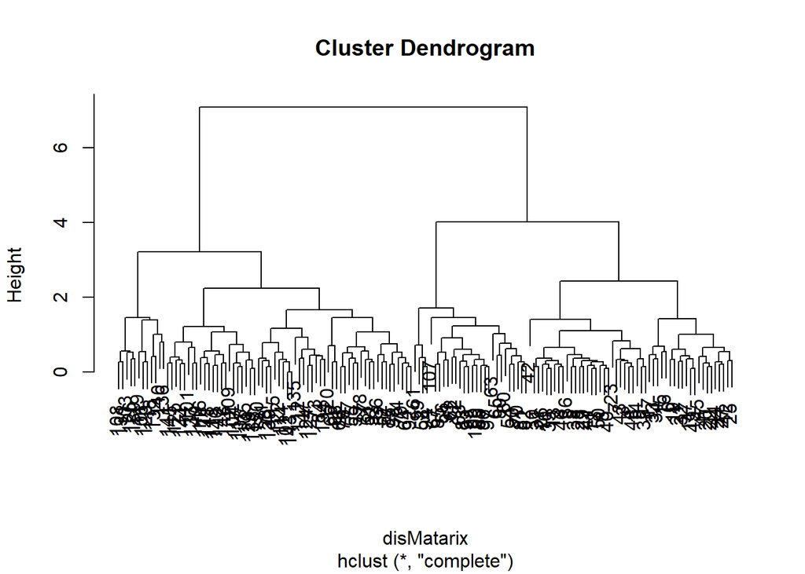

```r
ma <- as.matrix(iris[, 1:4]) # convert to matrix
disMatarix <- dist(ma)
plot(hclust(disMatarix))
```

We first calculate a distance matrix using the **dist()** function with the default Euclidean distance method. The distance matrix is then used by the **hclust1()** function to generate a hierarchical clustering tree with the default complete linkage method, which is then plotted in a nested command.

The 150 samples of flowers are organized in this cluster dendrogram based on their Euclidean distance, which is labeled vertically by the bar to the left side. Highly similar flowers are grouped together in smaller branches, and their distances can be found according to the vertical position of the branching point. We are often more interested in looking at the overall structure of the dendrogram. For example, we see two big clusters.

First, each of the flower samples is treated as a cluster. The algorithm joins the two most similar clusters based on a distance function. This is performed iteratively until there is just a single cluster containing all 150 flowers. At each iteration, the distances between clusters are recalculated according to one of the methods—*Single linkage, complete linkage, average linkage, and so on*. In the single-linkage method, the distance between two clusters is defined by the smallest distance among the all possible object pairs. This approach puts ‘friends of friends’ into a cluster. On the contrary, the complete linkage method defines the distance as the largest distance between object pairs. It finds similar clusters. Between these two extremes, there are many options in between. The linkage method I found the most robust is the average linkage method, which uses the average of all distances. However, the default seems to be the complete linkage. Thus we need to change that in our final version.

**Heat maps** with hierarchical clustering are my favorite way of visualizing data matrices. The rows and columns are reorganized based on hierarchical clustering, and the values in the matrix are coded by colors. Heat maps can directly visualize millions of numbers in one plot. The hierarchical trees also show the similarity among rows and columns.

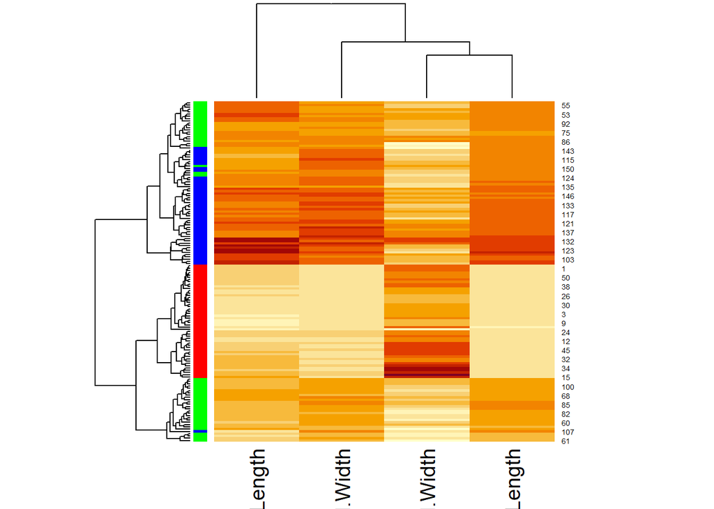

```r
heatmap(ma,
  scale = "column",
  RowSideColors = rainbow(3)[iris$Species]
)
```

```r
install.packages("pheatmap")
```

(ref:12-3) Heatmap for iris flower dataset.

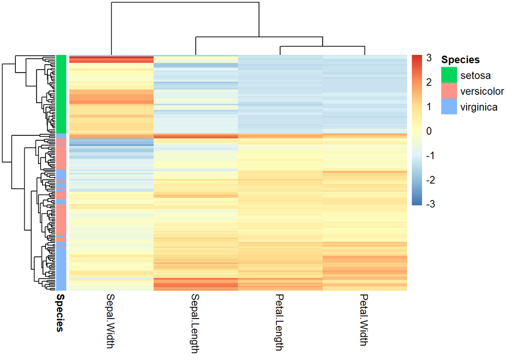

```r
library(pheatmap)
ma <- as.matrix(iris[, 1:4]) # convert to matrix
row.names(ma) <- row.names(iris) # assign row names in the matrix
pheatmap(ma,
  scale = "column",
  clustering_method = "average", # average linkage
  annotation_row = iris[, 5, drop = FALSE], # the 5th column as color bar
  show_rownames = FALSE
)
```

First, we convert the first 4 columns of the iris data frame into a matrix. Then the row names are assigned to be the same, namely, “1” to “150”. This is required because row names are used to match with the column annotation information, specified by the annotation_row parameter. Even though we only need the 5th column, i.e., Species, this has to be a data frame. To prevent R from automatically converting a one-column data frame into a vector, we used *drop = FALSE* option. Multiple columns can be contained in the column annotation data frame to display multiple color bars. The rows could be annotated the same way.

More information about the pheatmap function can be obtained by reading the help document. But most of the times, I rely on the online tutorials. Beyond the official documents prepared by the author, there are many documents created by R users across the world. The R user community is uniquely open and supportive. I was researching heatmap.2, a more refined version of heatmap part of the gplots package and landed on Dave Tang’s [blog](https://davetang.org/muse/2010/12/06/making-a-heatmap-with-r/), which mentioned that there is a more user-friendly package called pheatmap described in his other [blog](https://davetang.org/muse/2018/05/15/making-a-heatmap-in-r-with-the-pheatmap-package/). To figure out the code chuck above, I tried several times and also used Kamil Slowikowski’s [blog](https://slowkow.com/notes/pheatmap-tutorial/).

We can gain many insights from Figure @ref(fig:12-3). The 150 flowers in the rows are organized into different clusters. *I. Setosa* samples obviously formed a unique cluster, characterized by smaller (blue) petal length, petal width, and sepal length. The other two subspecies are not clearly separated but we can notice that some *I. Virginica* samples form a small subcluster showing bigger petals. The columns are also organized into dendrograms, which clearly suggest that petal length and petal width are highly correlated.

## Principal component analysis (PCA)

This section can be skipped, as it contains more statistics than R programming. To visualize high-dimensional data, we use PCA to map data to lower dimensions.

PCA is a linear dimension-reduction method. As illustrated in Figure @ref(fig:13-4), it tries to define a new set of orthogonal coordinates to represent the data such that the new coordinates can be ranked by the amount of variation or information it captures in the dataset. After running PCA, you get many pieces of information:

- How the new coordinates are defined,
- The percentage of variances captured by each of the new coordinates,
- A representation of all the data points onto the new coordinates.

(ref:13-4) Concept of PCA. Here the first component x’ gives a relatively accurate representation of the data.

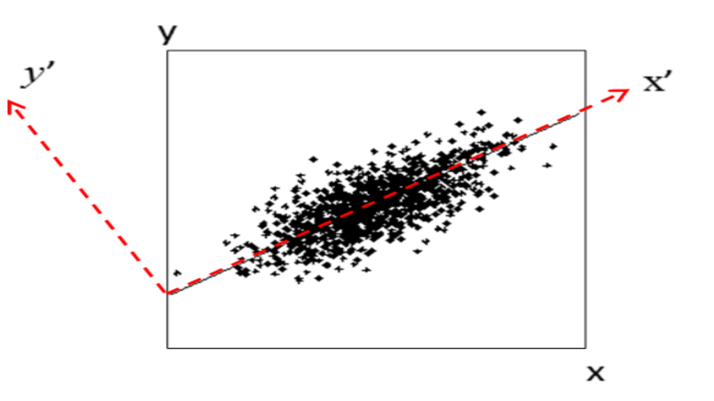

Here is an example of running PCA on the first 4 columns of the iris data. Note that “scale = TRUE” in the following command means that the data is normalized before conduction PCA so that each variable has unit variance.

```r
pca <- prcomp(iris[, 1:4], scale = TRUE)
pca # Have a look at the results.
```

```
## Standard deviations (1, .., p=4):
## [1] 1.7083611 0.9560494 0.3830886 0.1439265
##
## Rotation (n x k) = (4 x 4):
##                     PC1         PC2        PC3        PC4
## Sepal.Length  0.5210659 -0.37741762  0.7195664  0.2612863
## Sepal.Width  -0.2693474 -0.92329566 -0.2443818 -0.1235096
## Petal.Length  0.5804131 -0.02449161 -0.1421264 -0.8014492
## Petal.Width   0.5648565 -0.06694199 -0.6342727  0.5235971
```

The first principal component is positively correlated with Sepal length, petal length, and petal width. Recall that these three variables are highly correlated. Sepal width is the variable that is almost the same across three species with small standard deviation. PC2 is mostly determined by sepal width, less so by sepal length.

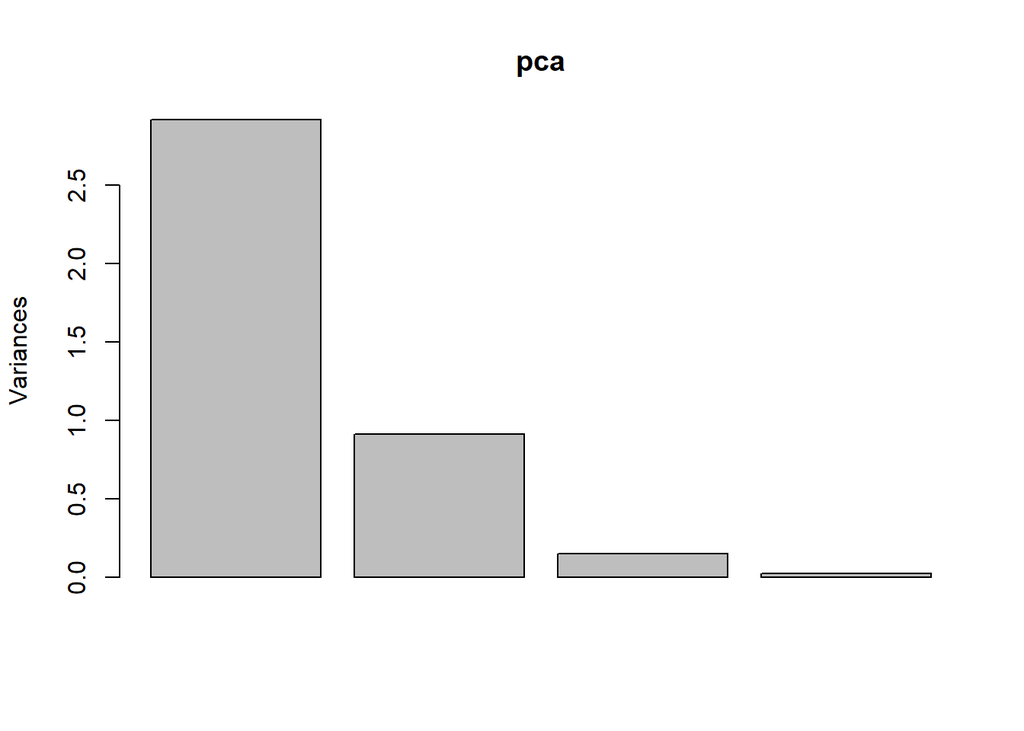

```r
plot(pca) # plot the amount of variance each principal components captures.
```

```r
str(pca) # this shows the structure of the object, listing all parts.
```

```
## List of 5
##  $ sdev    : num [1:4] 1.708 0.956 0.383 0.144
##  $ rotation: num [1:4, 1:4] 0.521 -0.269 0.58 0.565 -0.377 ...
##   ..- attr(*, "dimnames")=List of 2
##   .. ..$ : chr [1:4] "Sepal.Length" "Sepal.Width" "Petal.Length" "Petal.Width"
##   .. ..$ : chr [1:4] "PC1" "PC2" "PC3" "PC4"
##  $ center  : Named num [1:4] 5.84 3.06 3.76 1.2
##   ..- attr(*, "names")= chr [1:4] "Sepal.Length" "Sepal.Width" "Petal.Length" "Petal.Width"
##  $ scale   : Named num [1:4] 0.828 0.436 1.765 0.762
##   ..- attr(*, "names")= chr [1:4] "Sepal.Length" "Sepal.Width" "Petal.Length" "Petal.Width"
##  $ x       : num [1:150, 1:4] -2.26 -2.07 -2.36 -2.29 -2.38 ...
##   ..- attr(*, "dimnames")=List of 2
##   .. ..$ : NULL
##   .. ..$ : chr [1:4] "PC1" "PC2" "PC3" "PC4"
##  - attr(*, "class")= chr "prcomp"
```

```r
head(pca$x) # the new coordinate values for each of the 150 samples
```

```
##            PC1        PC2         PC3          PC4
## [1,] -2.257141 -0.4784238  0.12727962  0.024087508
## [2,] -2.074013  0.6718827  0.23382552  0.102662845
## [3,] -2.356335  0.3407664 -0.04405390  0.028282305
## [4,] -2.291707  0.5953999 -0.09098530 -0.065735340
## [5,] -2.381863 -0.6446757 -0.01568565 -0.035802870
## [6,] -2.068701 -1.4842053 -0.02687825  0.006586116
```

To plot the PCA results, we first construct a data frame with all information, as required by ggplot2.

```r
pcaData <- as.data.frame(pca$x[, 1:2]) # extract first two columns and convert to data frame
pcaData <- cbind(pcaData, iris$Species) # bind by columns
colnames(pcaData) <- c("PC1", "PC2", "Species") # change column names

library(ggplot2)
ggplot(pcaData) +
  aes(PC1, PC2, color = Species, shape = Species) + # define plot area
  geom_point(size = 2) # adding data points
```

[output not shown]

Now we have a basic plot. We can add elements one by one using the “+” sign at the end of the first line. We will add details to this plot.

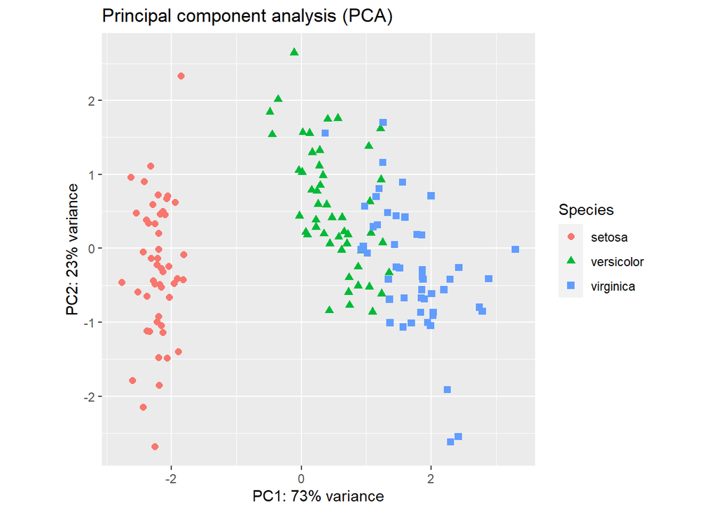

```r
percentVar <- round(100 * summary(pca)$importance[2, 1:2], 0) # compute % variances
ggplot(pcaData, aes(PC1, PC2, color = Species, shape = Species)) + # starting ggplot2
  geom_point(size = 2) + # add data points
  xlab(paste0("PC1: ", percentVar[1], "% variance")) + # x label
  ylab(paste0("PC2: ", percentVar[2], "% variance")) + # y label
  ggtitle("Principal component analysis (PCA)") + # title
  theme(aspect.ratio = 1) # width and height ratio
```

The result (Figure @ref(fig:13-5)) is a projection of the 4-dimensional iris flowering data on 2-dimensional space using the first two principal components. We can see that the first principal component alone is useful in distinguishing the three species. We could use simple rules like this: If PC1 < -1, then Iris setosa. If PC1 > 1.5 then Iris virginica. If -1 < PC1 < 1, then Iris versicolor.

```
>
Create PCA plot of the state.x77 data set (convert matrix to data frame).
Use the state.region information to color code the states. Interpret your results.
Hint: do not forget normalization using the scale option.
```

## Classification by predicting the odds of binary outcomes

This section can be skipped, as it contains more statistics than R programming. It is easy to distinguish *I. setosa* from the other two species, just based on petal length alone. Here we focus on building a predictive model that can predict between *I. versicolor* and *I. virginica*. For this purpose, we use the logistic regression to model the odds ratio of being *I. virginica* as a function of all of the 4 measurements:

$$ln(odds)=ln(\frac{p}{1-p})
=a×Sepal.Length + b×Sepal.Width + c×Petal.Length +
d×Petal.Width+c+e.$$

```r
df <- iris[51:150, ] # removes the first 50 samples, which represent I. setosa
df <- droplevels(df) # removes setosa, an empty levels of species.
model <- glm(Species ~ ., # Model: Species as a function of other variables
  family = binomial(link = "logit"),
  data = df
)
summary(model)
```

```
##
## Call:
## glm(formula = Species ~ ., family = binomial(link = "logit"),
##     data = df)
##
## Coefficients:
##              Estimate Std. Error z value Pr(>|z|)
## (Intercept)   -42.638     25.707  -1.659   0.0972 .
## Sepal.Length   -2.465      2.394  -1.030   0.3032
## Sepal.Width    -6.681      4.480  -1.491   0.1359
## Petal.Length    9.429      4.737   1.991   0.0465 *
## Petal.Width    18.286      9.743   1.877   0.0605 .
## ---
## Signif. codes:  0 '***' 0.001 '**' 0.01 '*' 0.05 '.' 0.1 ' ' 1
##
## (Dispersion parameter for binomial family taken to be 1)
##
##     Null deviance: 138.629  on 99  degrees of freedom
## Residual deviance:  11.899  on 95  degrees of freedom
## AIC: 21.899
##
## Number of Fisher Scoring iterations: 10
```

Sepal length and width are not useful in distinguishing versicolor from *virginica*. The most significant (P=0.0465) factor is Petal.Length. One unit increase in petal length will increase the log-odds of being *virginica* by 9.429. A marginally significant effect is found for Petal.Width.

If you do not fully understand the mathematics behind linear regression or logistic regression, do not worry about it too much. In this class, I just want to show you how to do these analyses in R and interpret the results. I do not understand how computers work. Yet I **use** it every day.

The best way to learn R is to use it. After the first two chapters, it is entirely possible to start working on a your own dataset. If you do not have a dataset, you can find one from sources such as [TidyTuesday](https://github.com/rfordatascience/tidytuesday).  
You do not need to finish the rest of this book. Set a goal or a research question. Feel free to search for and steal some example code.

```
>
So far, we used a variety of techniques to investigate the iris flower dataset. Recall that in the very beginning, I asked you to eyeball the data and answer two questions:
>
a.  What distinguishes these three species?
b.  If we have a flower with sepals of 6.5cm long and 3.0cm wide, petals of 6.2cm long, and 2.2cm wide, which species does it most likely belong to?
>
Review all the analysis we did, examine the raw data, and answer the above questions. Write a paragraph and provide evidence of your thinking. Do more analysis if needed.
```

References: 1 Beckerman, A. (2017). Getting started with r second edition. New York, NY, Oxford University Press.